# Part I - (Prosper Loan Dataset)

#### Relationship Between Categorical Features (post09 data)

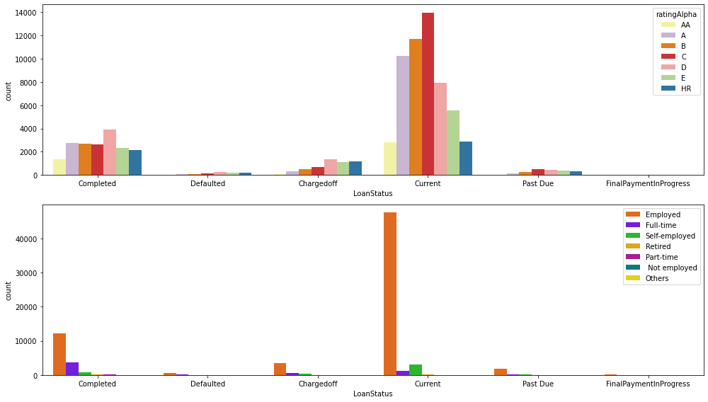

```python
ords = ['AA', 'A', 'B', 'C', 'D', 'E','HR']
ords1 =['Employed','Full-time','Self-employed',  'Retired','Part-time', ' Not employed','Others']

plt.figure(figsize = [14, 8])

plt.subplot(2, 1, 1)
sb.countplot(data = post09, x = 'LoanStatus', hue = 'ratingAlpha', palette = 'Paired_r', hue_order=ords)


ax = plt.subplot(2, 1, 2)
sb.countplot(data = post09, x = 'LoanStatus', hue = 'EmploymentStatus', palette = 'prism_r', hue_order =ords1)
ax.legend(loc=1)

plt.tight_layout()
plt.show();
```

##### A larger percentage or the loans recorded between the year 2010 and 2015 are still running or yet to be paid

### Violin plot of data before 2010

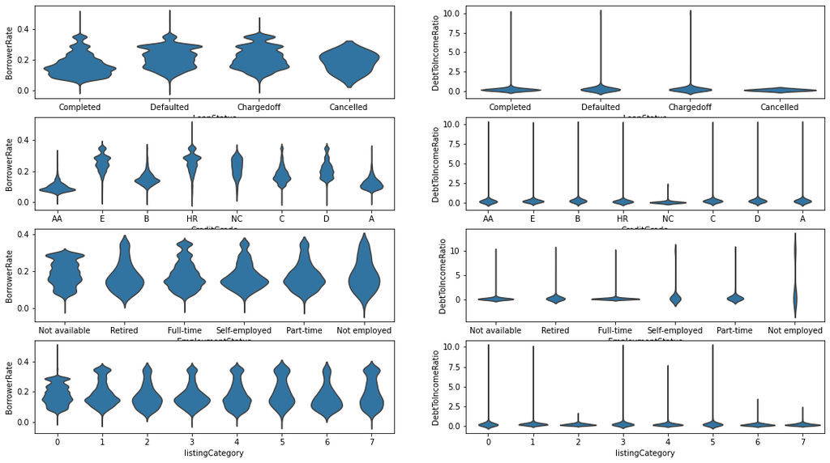

```python
fig, ax = plt.subplots(ncols = 2, nrows = 4 , figsize = [18,10])

for i in range(len(cat_vari)):
    var = cat_vari[i]
    sb.violinplot(data = pre09, x = var, y = 'BorrowerRate', inner = None, ax = ax[i,0],
               color = base_color)
    sb.violinplot(data = pre09, x = var, y = 'DebtToIncomeRatio', inner = None, ax = ax[i,1],
               color = base_color)
plt.show()
```

### Violin Plot of data from 2010

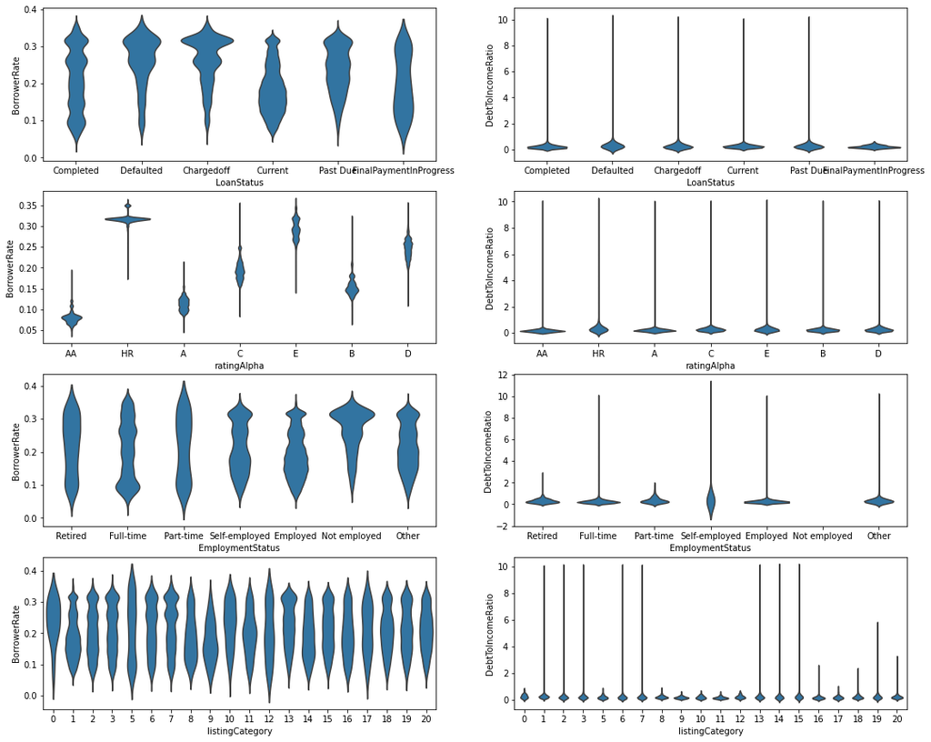

```python
fig, ax = plt.subplots(ncols = 2, nrows = 4 , figsize = [18,15])

for i in range(len(cat_vari1)):
    var = cat_vari1[i]
    sb.violinplot(data = post09, x = var, y = 'BorrowerRate', inner = None, ax = ax[i,0],
               color = base_color)
    sb.violinplot(data = post09, x = var, y = 'DebtToIncomeRatio', inner = None,  ax = ax[i,1],
               color = base_color)
plt.show()
```

The category of the listing that the borrower selected when posting their listing: 0 - Not Available, 1 - Debt Consolidation, 2 - Home Improvement, 3 - Business, 4 - Personal Loan, 5 - Student Use, 6 - Auto, 7- Other, 8 - Baby&Adoption, 9 - Boat, 10 - Cosmetic Procedure, 11 - Engagement Ring, 12 - Green Loans, 13 - Household Expenses, 14 - Large Purchases, 15 - Medical/Dental, 16 - Motorcycle, 17 - RV, 18 - Taxes, 19 - Vacation, 20 - Wedding Loans

## Multivariate Exploration

> Create plots of three or more variables to investigate your data even further. Make sure that your investigations are justified, and follow from your work in the previous sections.

### Scatter Plot of Data pre 09 using Loan Status as Marker

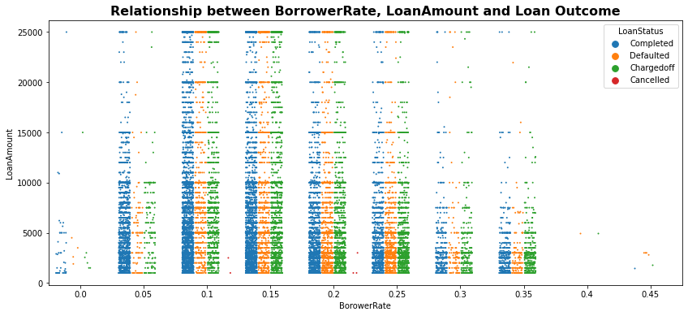

```python
plt.figure(figsize =(14,6))

pre09['int_rate']= (((pre09['BorrowerRate']*100)//5)/20)

sb.stripplot(data =pre09, x= 'int_rate', y='LoanOriginalAmount', hue='LoanStatus',  size =2, jitter =0.35, dodge= True)
plt.title('Relationship between BorrowerRate, LoanAmount and Loan Outcome', fontsize =16, fontweight =  'bold')
plt.ylabel('LoanAmount')
plt.xlabel('BorowerRate');
```

### Scatter Plot of Data post 09 using Loan Status as Marker

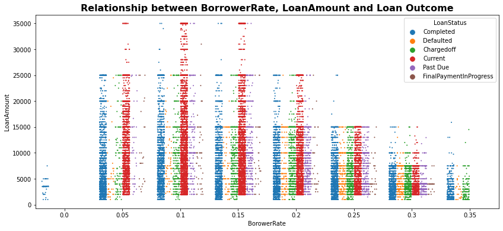

```python
plt.figure(figsize =(14,6))

post09['int_rate']= (((post09['BorrowerRate']*100)//5)/20)

sb.stripplot(data =post09, x= 'int_rate', y='LoanOriginalAmount', hue='LoanStatus',  size =2, jitter =0.35, dodge= True)
plt.title('Relationship between BorrowerRate, LoanAmount and Loan Outcome', fontsize =16, fontweight =  'bold')
plt.ylabel('LoanAmount')
plt.xlabel('BorowerRate');
```

Creating a Mask to examine how each loan varies with respect to BorrowerRate

```python
# Creating  mask where borrower rate less than 15% as low and greater than 15% as high for data pre09
low =pre09.BorrowerRate <=0.15
high = pre09.BorrowerRate >0.15

# Creating  mask where borrower rate less than 15% as low1 and greater than 15% as high1 for data post09
low1 =post09.BorrowerRate <=0.15
high1 = post09.BorrowerRate >0.15
```

### Faceting in two direction of data pre09 with BorrowerRate less than 15%

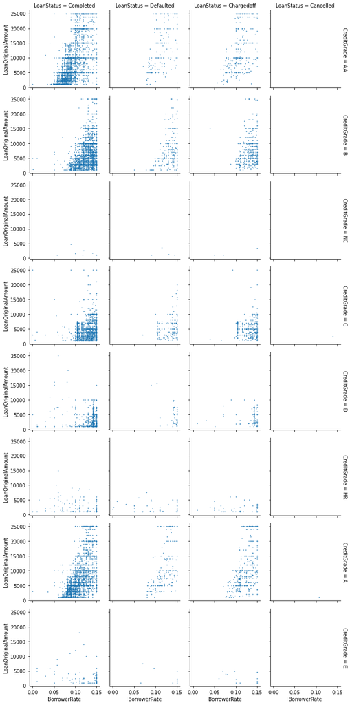

```python
g = sb.FacetGrid(data = pre09[low], col = 'LoanStatus', row = 'CreditGrade', height = 2.5,
                margin_titles = True)
g.map(plt.plot, 'BorrowerRate', 'LoanOriginalAmount', linestyle='', marker='o', markersize=0.7);
```

**The plot above reveal that loans outcome tend to follow the same pattern for different grade of borrower. As the credit grade keep moving from AA , A, B, C, D, E through HR the borrowers interest rate tend to increase.**

### Faceting in two direction of data pre09 with BorrowerRate greater than 15%

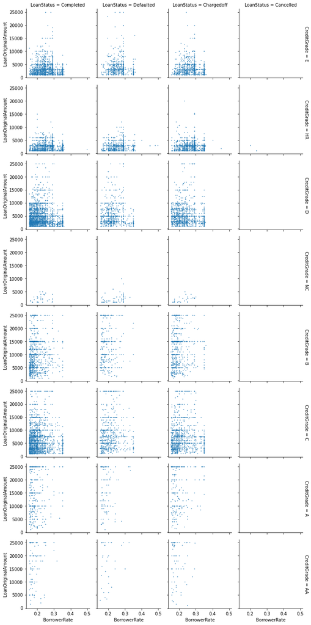

```python
g = sb.FacetGrid(data = pre09[high], col = 'LoanStatus', row = 'CreditGrade', height = 2.5,
                margin_titles = True)
g.map(plt.plot, 'BorrowerRate', 'LoanOriginalAmount', linestyle='', marker='o', markersize=0.7);
```

**The plot above reveal that loans outcome tend to follow the same pattern for different grade of borrower. As the credit grade keep moving from AA , A, B, C, D, E through HR the borrowers interest rate tend to increase.**

### Faceting in two direction of data post09 with BorrowerRate less than 15%

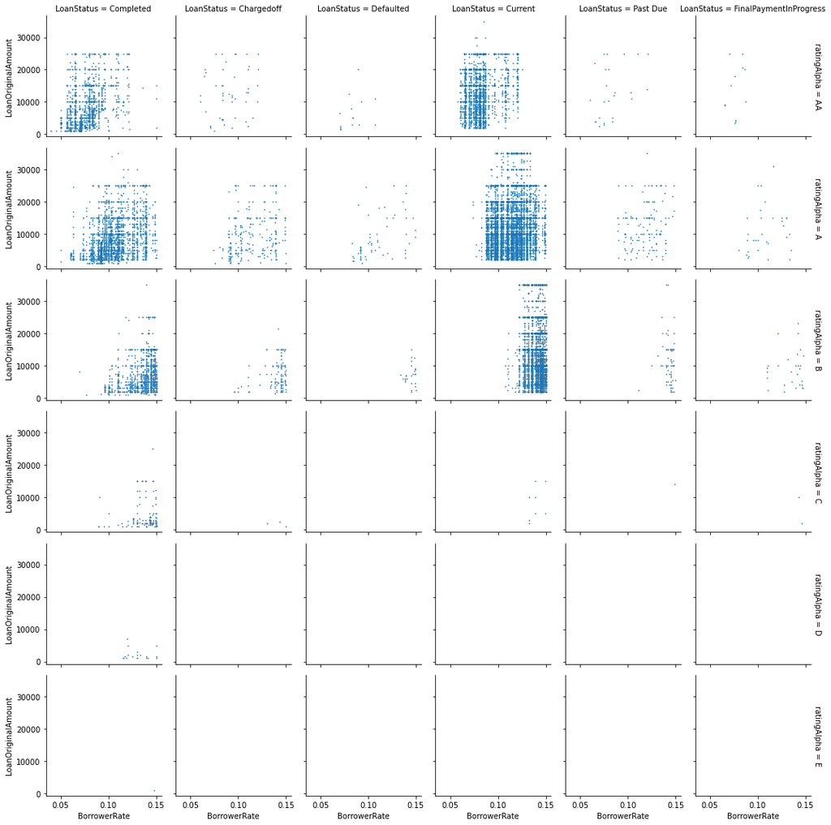

```python
g = sb.FacetGrid(data = post09[low1], col = 'LoanStatus', row = 'ratingAlpha', height = 2.5,
                margin_titles = True)
g.map(plt.plot, 'BorrowerRate', 'LoanOriginalAmount', linestyle='', marker='o', markersize=0.7);
```

**The plot above reveal that loans outcome tend to follow the same pattern for different rating of borrower. As the rating grade keeps moving from AA , A, B, C, D through E the borrowers interest rate tend to increase. As a result, little to no loans with interest rate less than 15% were obtainable by borrowers with rating C, D & E**

### Faceting in two direction of data post09 with BorrowerRate greater than 15%

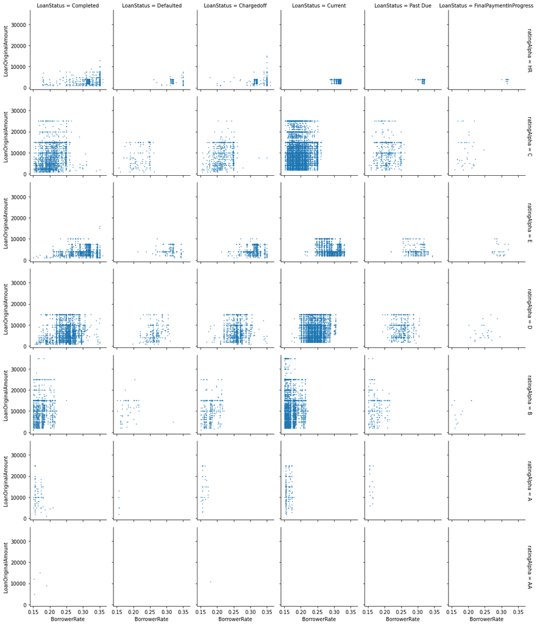

```python
g = sb.FacetGrid(data = post09[high1], col = 'LoanStatus', row = 'ratingAlpha', height = 2.5,
                margin_titles = True)
g.map(plt.plot, 'BorrowerRate', 'LoanOriginalAmount', linestyle='', marker='o', markersize=0.7);
```

**The plot above reveal that more loans with borrower interest rate more than 15% were obtained by borrower with rating grade C, D, E, HR. Borrowers with rating grade AA & A obtained a few loans with interest rate greater than 15%**

### Talk about some of the relationships you observed in this part of the investigation. Were there features that strengthened each other in terms of looking at your feature(s) of interest?

> Also, for both data (pre09 and post09), I try examining the relationship between loans that has high interest rate compared with those with low interest rate